# BIOS611 Project 1

Salim Hyder

September 14, 2018

# Introduction

In this project we select four datasets from R dataset package for Exploratory analysis.

To begin with I load the library tidyverse.

```r
library(tidyverse)
data()
```

## Exploratory analysis for dataset 1

I select iris dataset as my first data

A numerical summary of the iris data set is given as follows:

```r
summary(tp1)
```

```
##   Sepal.Length    Sepal.Width     Petal.Length    Petal.Width
##  Min.   :4.300   Min.   :2.000   Min.   :1.000   Min.   :0.100
##  1st Qu.:5.100   1st Qu.:2.800   1st Qu.:1.600   1st Qu.:0.300
##  Median :5.800   Median :3.000   Median :4.350   Median :1.300
##  Mean   :5.843   Mean   :3.057   Mean   :3.758   Mean   :1.199
##  3rd Qu.:6.400   3rd Qu.:3.300   3rd Qu.:5.100   3rd Qu.:1.800
##  Max.   :7.900   Max.   :4.400   Max.   :6.900   Max.   :2.500
##        Species      names
##  setosa    :50   Length:150
##  versicolor:50   Class :character
##  virginica :50   Mode  :character
##
##
##
```

# Graphical Summary:Box plots

Select column with select()

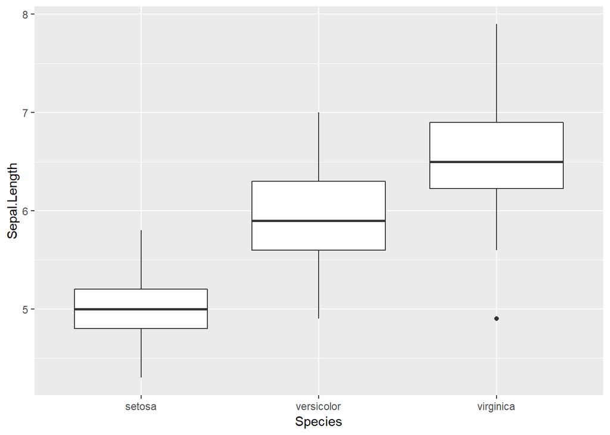

```r
sl <- select(tp1, Species, Sepal.Length, Sepal.Width, Petal.Length, Petal.Width)
 ggplot(sl, mapping=aes(x=Species, y=Sepal.Length)) +
    geom_boxplot()
```

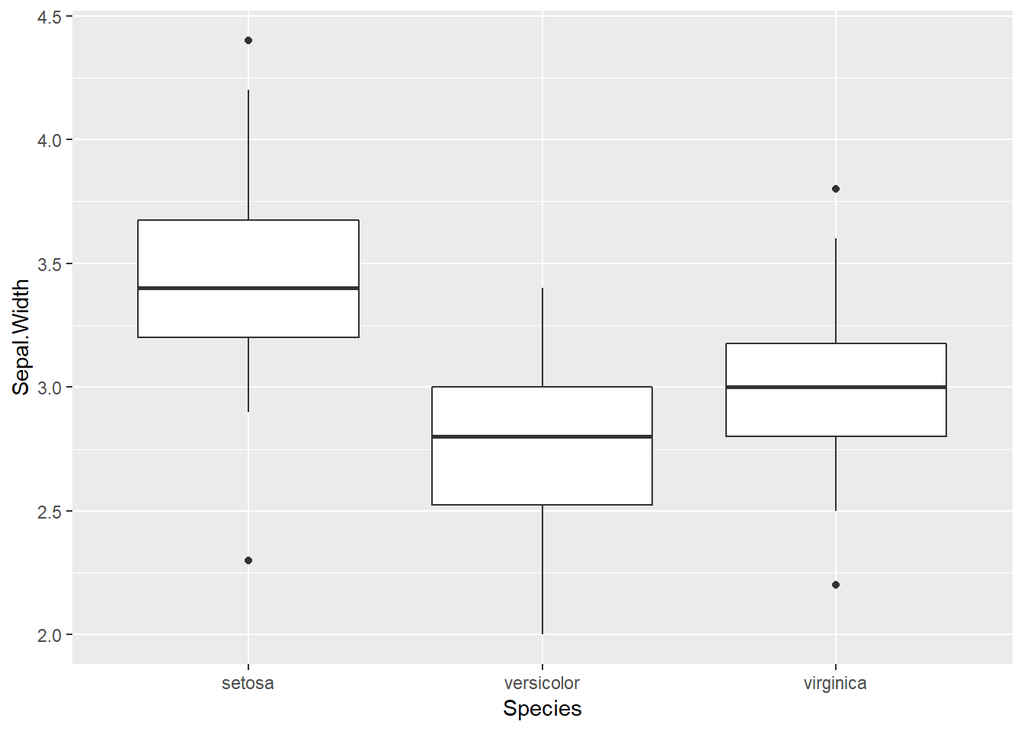

```r
 ggplot(sl, mapping=aes(x=Species, y=Sepal.Width)) +
    geom_boxplot()
```

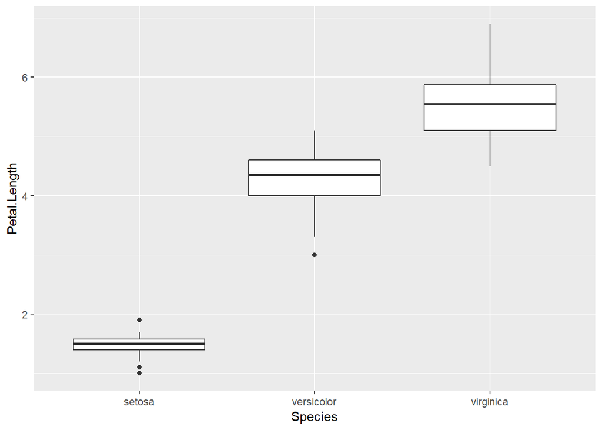

```r
 ggplot(sl, mapping=aes(x=Species, y=Petal.Length)) +
    geom_boxplot()
```

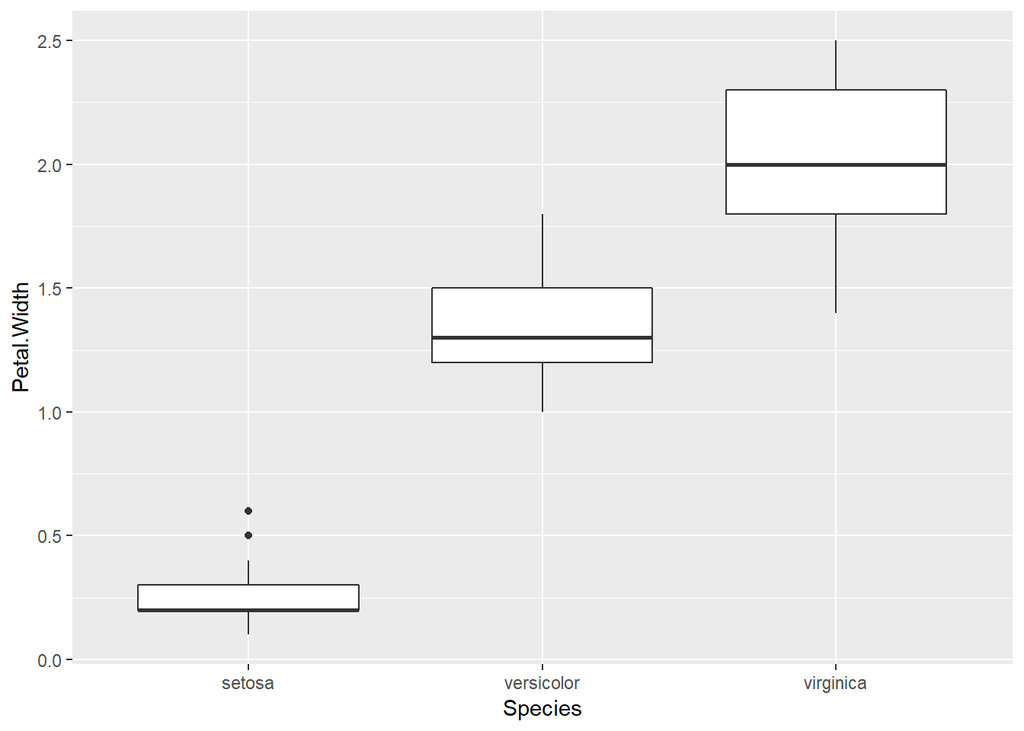

```r
 ggplot(sl, mapping=aes(x=Species, y=Petal.Width)) +
    geom_boxplot()
```

Median Sepal Length of species ‘virginica’ is higher than the median lenghts of species ‘setosa’ and ‘versicilor’. Variation of length within species ‘virginica’ is also higher than the variations of lengths of species ‘setosa’ and ‘versicilor’

The dataset can be filtered to create plots only for one species: virginica

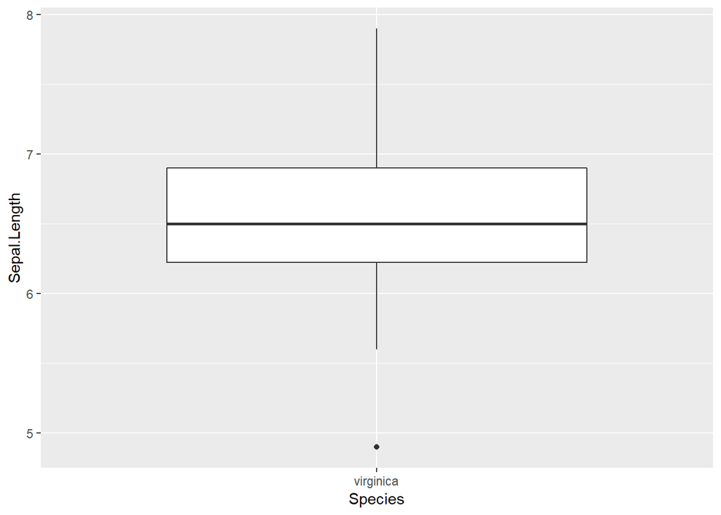

```r
fl1 <- filter(tp1, Species == 'virginica')
ggplot(fl1, mapping=aes(x=Species, y=Sepal.Length)) +
    geom_boxplot()
```

## Exploratory analysis for dataset 2

The CO2 data frame has 84 rows and 5 columns of data from an experiment on the cold tolerance of the grass species Echinochloa crus-galli. One possible analysis would be determine how uptake of CO2 depends on ambient concentration.

I select CO2 dataset as my second data

A numerical summary of the CO2 data set is given as follows:

```r
summary(CO2)
```

```
##      Plant             Type         Treatment       conc
##  Qn1    : 7   Quebec     :42   nonchilled:42   Min.   :  95
##  Qn2    : 7   Mississippi:42   chilled   :42   1st Qu.: 175
##  Qn3    : 7                                    Median : 350
##  Qc1    : 7                                    Mean   : 435
##  Qc3    : 7                                    3rd Qu.: 675
##  Qc2    : 7                                    Max.   :1000
##  (Other):42
##      uptake
##  Min.   : 7.70
##  1st Qu.:17.90
##  Median :28.30
##  Mean   :27.21
##  3rd Qu.:37.12
##  Max.   :45.50
##
```

# Graphical Summary

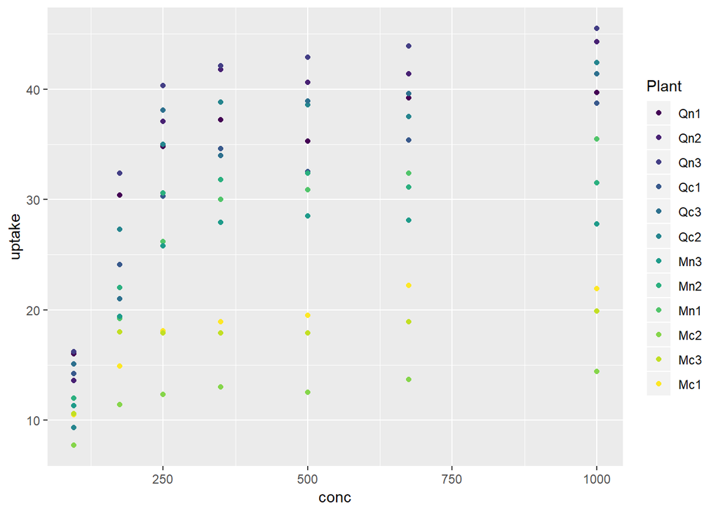

```r
ggplot(data=tp2) +
   geom_point(mapping = aes(x = conc, y = uptake, color = Plant))
```

Co2 uptake increases with the increase of ambient Co2 concentration in Quebec plants.

Same analysis could be shown within a particular treatment group. The dataset can be filtered to create plots only for one treatment: nonchilled

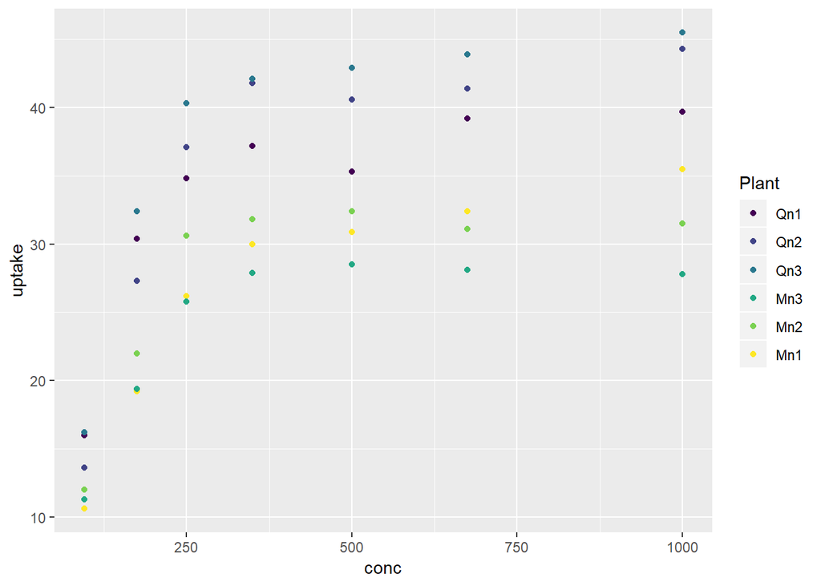

```r
fl2 <- filter(tp2, Treatment=='nonchilled')
ggplot(data=fl2) +
   geom_point(mapping = aes(x = conc, y = uptake, color = Plant))
```

## Exploratory analysis for dataset 3

I select USArrests dataset as my second data

A numerical summary of the USArrests data set is given as follows:

```r
summary(USArrests)
```

```
##      Murder          Assault         UrbanPop          Rape
##  Min.   : 0.800   Min.   : 45.0   Min.   :32.00   Min.   : 7.30
##  1st Qu.: 4.075   1st Qu.:109.0   1st Qu.:54.50   1st Qu.:15.07
##  Median : 7.250   Median :159.0   Median :66.00   Median :20.10
##  Mean   : 7.788   Mean   :170.8   Mean   :65.54   Mean   :21.23
##  3rd Qu.:11.250   3rd Qu.:249.0   3rd Qu.:77.75   3rd Qu.:26.18
##  Max.   :17.400   Max.   :337.0   Max.   :91.00   Max.   :46.00
```

A sinpme analysis could be to determine how each type of crime depends on percentage of urban population

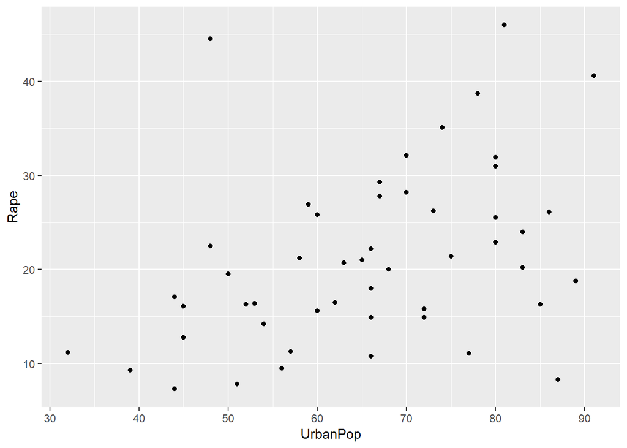

```r
ggplot(data=tp3) +
   geom_point(mapping = aes(x = UrbanPop, y = Rape))
```

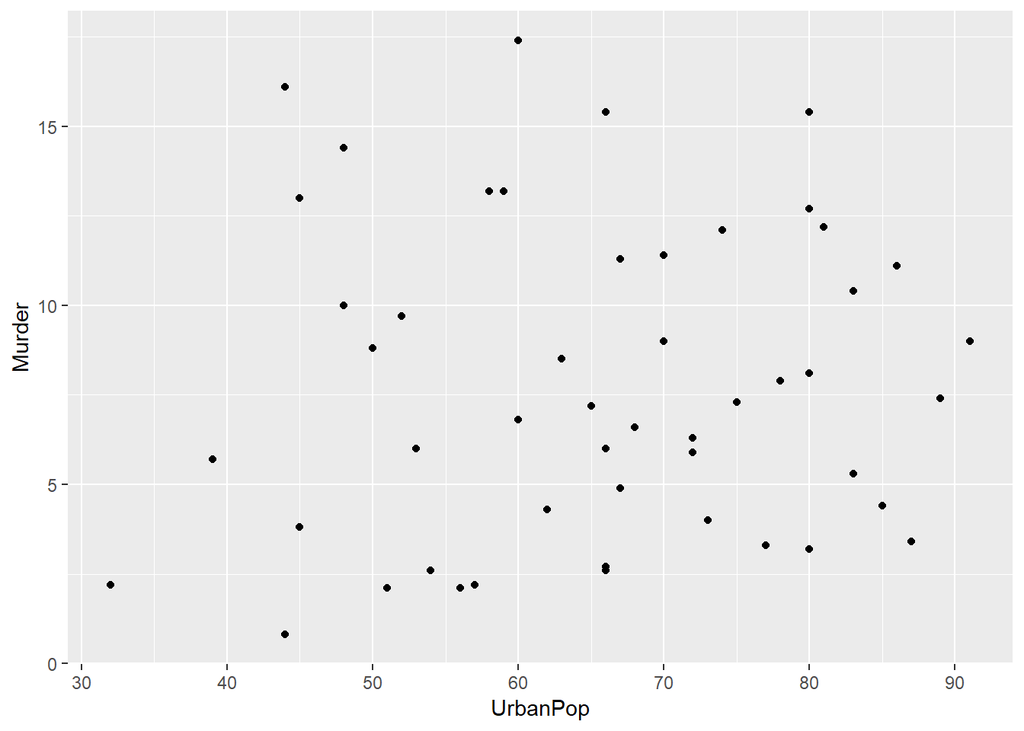

```r
ggplot(data=tp3) +
   geom_point(mapping = aes(x = UrbanPop, y = Murder))
```

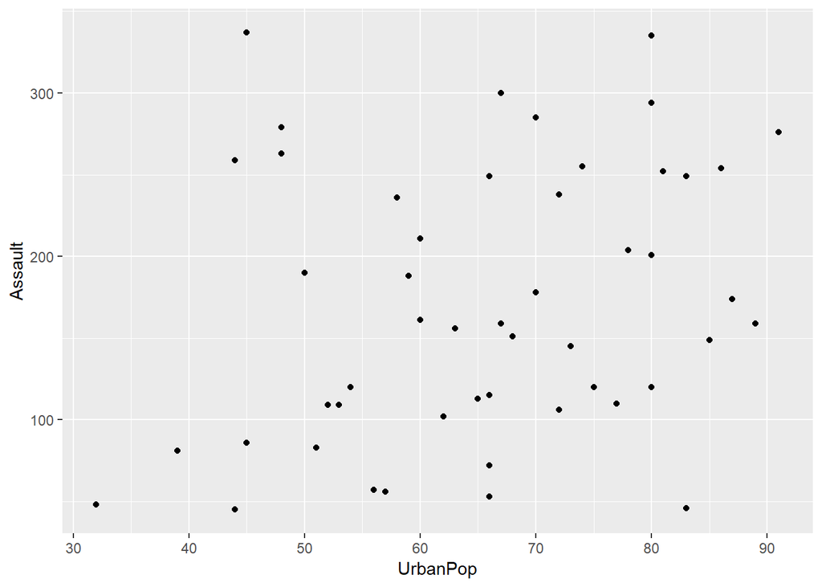

```r
ggplot(data=tp3) +
   geom_point(mapping = aes(x = UrbanPop, y = Assault))
```

## Exploratory analysis for dataset 4

I select ChickWeight dataset as my second data

Reasonable analysis will be to see how weight varies over time by different levels of diet

A numerical summary of the ChickWeight data set is given as follows:

```r
summary(ChickWeight)
```

```
##      weight           Time           Chick     Diet
##  Min.   : 35.0   Min.   : 0.00   13     : 12   1:220
##  1st Qu.: 63.0   1st Qu.: 4.00   9      : 12   2:120
##  Median :103.0   Median :10.00   20     : 12   3:120
##  Mean   :121.8   Mean   :10.72   10     : 12   4:118
##  3rd Qu.:163.8   3rd Qu.:16.00   17     : 12
##  Max.   :373.0   Max.   :21.00   19     : 12
##                                  (Other):506
```

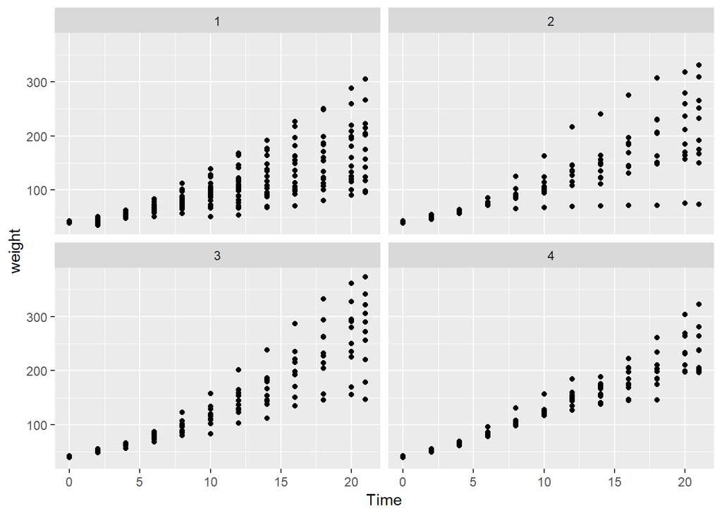

```r
ggplot(data=tp4) +
   geom_point(mapping = aes(x = Time, y = weight)) +
   facet_wrap(~ Diet, nrow=2)
```

Variable weight increases with the increase of time by different levels of diet